# Homework 2

Gülşah Akçakır - IE582 - Fall 2018

25 Ekim 2018

# Task 1

Firstly, the given datasets are examined and prepared to be used in the following steps.

The column *score* splitted into two (i.e. HomeGoals and AwayGoals) and new columns are converted to numeric values.

```r
matches[,c("HomeGoals","AwayGoals"):= tstrsplit(score,':')]

matches$HomeGoals <- as.numeric(matches$HomeGoals)
matches[,AwayGoals:= as.numeric(AwayGoals)]
```

Additionally, *IsOver* and *Result* columns are created.

```r
matches[,TotalGoals:= HomeGoals + AwayGoals]
matches[,IsOver:=0]
matches[TotalGoals>2,IsOver:=1]

matches[,Result:=0]
matches[HomeGoals>AwayGoals,Result:=1]
matches[HomeGoals<AwayGoals,Result:=2]
```

Format of the final table is as below:

```
##     matchId        home            away score Year HomeGoals AwayGoals
## 1: KjF6FiA6   tottenham manchester city   0:0 2010         0         0
## 2: ILVbJgQm aston villa        west ham   3:0 2010         3         0
## 3: SGIEDVvJ      wolves      stoke city   2:1 2010         2         1
## 4: YwL5xFHJ      bolton          fulham   0:0 2010         0         0
## 5: lQJAEBPC       wigan       blackpool   0:4 2010         0         4
## 6: byRcHDuf  sunderland      birmingham   2:2 2010         2         2
##    TotalGoals IsOver Result
## 1:          0      0      0
## 2:          3      1      1
## 3:          3      1      1
## 4:          0      0      0
## 5:          4      1      2
## 6:          4      1      0
```

```r
odds <- odd_details[bookmaker%in%c("Pinnacle","Betsafe","bet-at-home","Unibet","Betway")]
```

Only final odds of bookmakers are kept.

```r
odds_final=odds[,list(final_odd=odd[.N]),
                      by=list(matchId,oddtype,bookmaker)]
```

Odds dataset is widened with respect to oddtype and bookmaker. Then two datasets are combined.

```r
odds_wide_fin <- dcast(odds_final,
                       matchId~oddtype+bookmaker,
                       value.var = 'final_odd')

ou_wide_fin <-merge(odds_wide_fin,matches_2,by="matchId")
```

The final look of the data to be analyzed as follows:

```
##     matchId odd1_Betsafe odd1_Betway odd1_Pinnacle odd1_Unibet
## 1: 004f4ING         1.64        1.62          1.67        1.66
## 2: 02oVDuv1         1.85        1.83          1.83        1.85
## 3: 04PCiQzK         1.47        1.50          1.47        1.53
## 4: 04vrPwsg         2.01        2.05          2.06        2.00
## 5: 04zko0D5         1.15        1.15          1.14        1.16
## 6: 061xSktd         2.38        2.29          2.27        2.25
##    odd1_bet-at-home odd2_Betsafe odd2_Betway odd2_Pinnacle odd2_Unibet
## 1:             1.61         5.75        6.00          5.95        5.70
## 2:             1.78         4.75        4.75          5.00        4.80
## 3:             1.50         7.60        6.75          8.50        6.75
## 4:             1.96         4.20        4.00          4.18        4.15
## 5:             1.13        20.00       23.00         23.00       23.00
## 6:             2.20         2.95        2.75          3.31        3.30
##    odd2_bet-at-home oddX_Betsafe oddX_Betway oddX_Pinnacle oddX_Unibet
```

[output cut: 27 more lines]

Finally, repeated rows and rows with NA’s are eliminated.

```r
#to eliminate repeated rows
ou_wide_fin <-unique(ou_wide_fin)

#to remove rows with NA values
ou_wide_fin <-ou_wide_fin[complete.cases(ou_wide_fin),]
```

### Part a

In this part of task, PCA is applied and results are examined.

```r
pca<-princomp(ou_wide_fin, cor=T) #cor=T is selected in order to have a scaled data
```

It can be easily observed that with PCA it is possible to cover almost 90% of the total variance by only 8 components instead of 25. I will be using first 2 (sometimes 3) components for visualization purpose.

```r
summary(pca, loadings=F)
```

```
## Importance of components:
##                           Comp.1    Comp.2     Comp.3     Comp.4
## Standard deviation     3.1907964 2.1785139 1.30780861 1.19534248
## Proportion of Variance 0.4072473 0.1898369 0.06841453 0.05715375
## Cumulative Proportion  0.4072473 0.5970842 0.66549871 0.72265246
##                            Comp.5     Comp.6     Comp.7    Comp.8
## Standard deviation     1.11230847 1.05576735 1.00761009 0.9666334
## Proportion of Variance 0.04948921 0.04458579 0.04061112 0.0373752
## Cumulative Proportion  0.77214166 0.81672745 0.85733857 0.8947138
##                            Comp.9   Comp.10    Comp.11   Comp.12
## Standard deviation     0.88405146 0.8123577 0.75714986 0.6222458
## Proportion of Variance 0.03126188 0.0263970 0.02293104 0.0154876
## Cumulative Proportion  0.92597565 0.9523727 0.97530370 0.9907913
##                            Comp.13     Comp.14     Comp.15      Comp.16
## Standard deviation     0.300067317 0.174525931 0.136373937 0.1230594770
## Proportion of Variance 0.003601616 0.001218372 0.000743914 0.0006057454
## Cumulative Proportion  0.994392907 0.995611279 0.996355193 0.9969609382
##                             Comp.17      Comp.18      Comp.19      Comp.20
## Standard deviation     0.1170496951 0.1116131537 0.1004739241 0.0962349599
## Proportion of Variance 0.0005480252 0.0004982998 0.0004038004 0.0003704467
## Cumulative Proportion  0.9975089635 0.9980072633 0.9984110637 0.9987815104
##                             Comp.21      Comp.22      Comp.23      Comp.24
## Standard deviation     0.0934258576 0.0838514205 0.0791187228 0.0658666516
## Proportion of Variance 0.0003491356 0.0002812424 0.0002503909 0.0001735366
## Cumulative Proportion  0.9991306460 0.9994118884 0.9996622793 0.9998358160
##                            Comp.25
## Standard deviation     0.064067160
## Proportion of Variance 0.000164184
## Cumulative Proportion  1.000000000
```

2-dimensional scatter plot of the PCA components as is below and colors representing over/under results of the games.

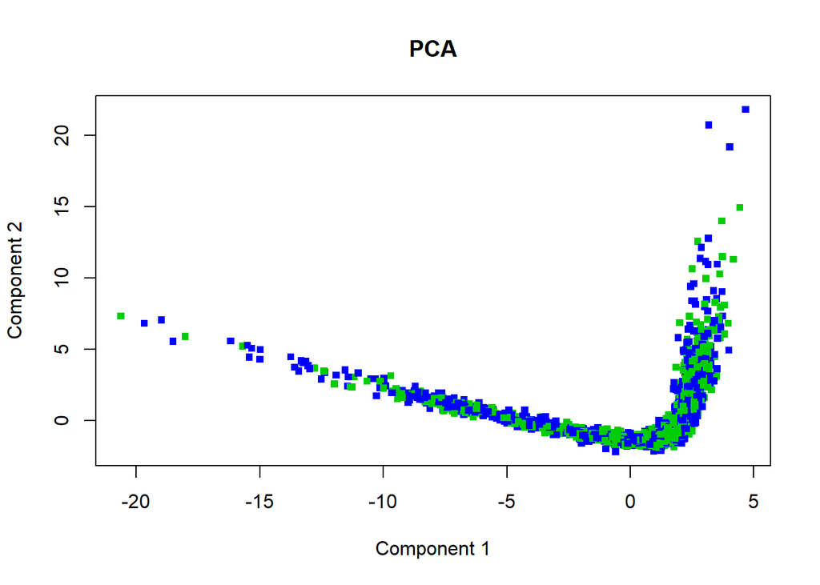

```r
plot(pca$scores[,1],pca$scores[,2],main= "PCA",xlab = "Component 1", ylab= "Component 2",col=a+3,pch=".",cex=6)
```

From this plot it is hard to say that they can be classified based on odd data of bookmakers.

Let’s include third component and see 3-dimensional plot.

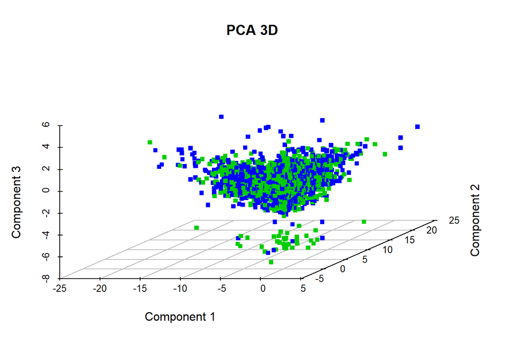

```r
scatterplot3d(pca$scores[,1:3],
              main="PCA 3D",
              xlab = "Component 1",
              ylab = "Component 2",
              zlab = "Component 3",
              color=a+3,
              pch = ".",
              cex.symbols = 6,
              box = FALSE)
```

Here again, they do not seem linearly seperable.

### Part b

In this part MDS is applied to the same data using both *Manhattan* and *Euclidean* distances.

First distance matrices are created.

```r
dist_manhattan <- dist(ou_wide_fin,method = "manhattan")
dist_euclidean <- dist(ou_wide_fin)
```

Then Multidimensional Scaling is applied for each case.

```r
fit <- cmdscale(dist_manhattan,eig=TRUE, k=2) # k is the number of dim
fit_2 <- cmdscale(dist_euclidean,eig=TRUE, k=2)
```

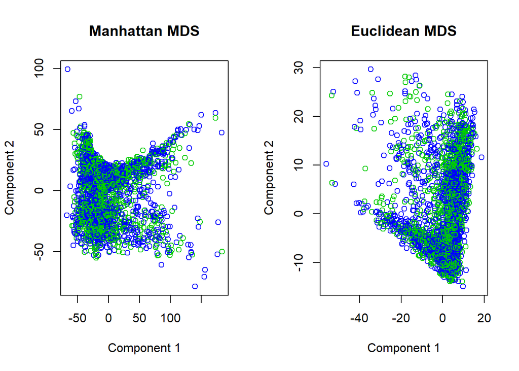

```r
par(mfrow=c(1,2))
plot(x,y, xlab="Component 1", ylab="Component 2",
     main="Manhattan MDS",col=a+3)
plot(k,j, xlab="Component 1", ylab="Component 2",
     main="Euclidean MDS",col=a+3)
```

### Part c

To compare the results obtained from each approach (PCA and MDS), 2D and 3D plots are respresented together.

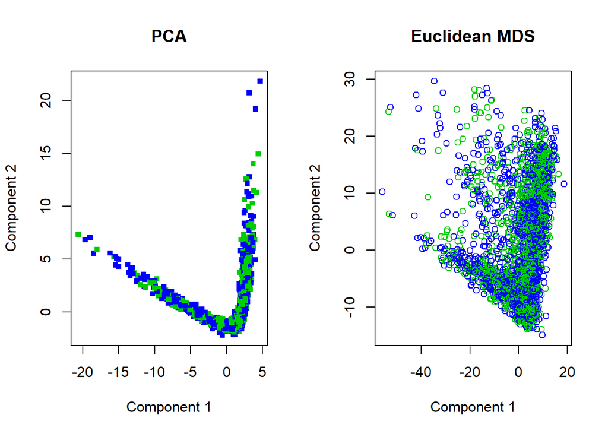

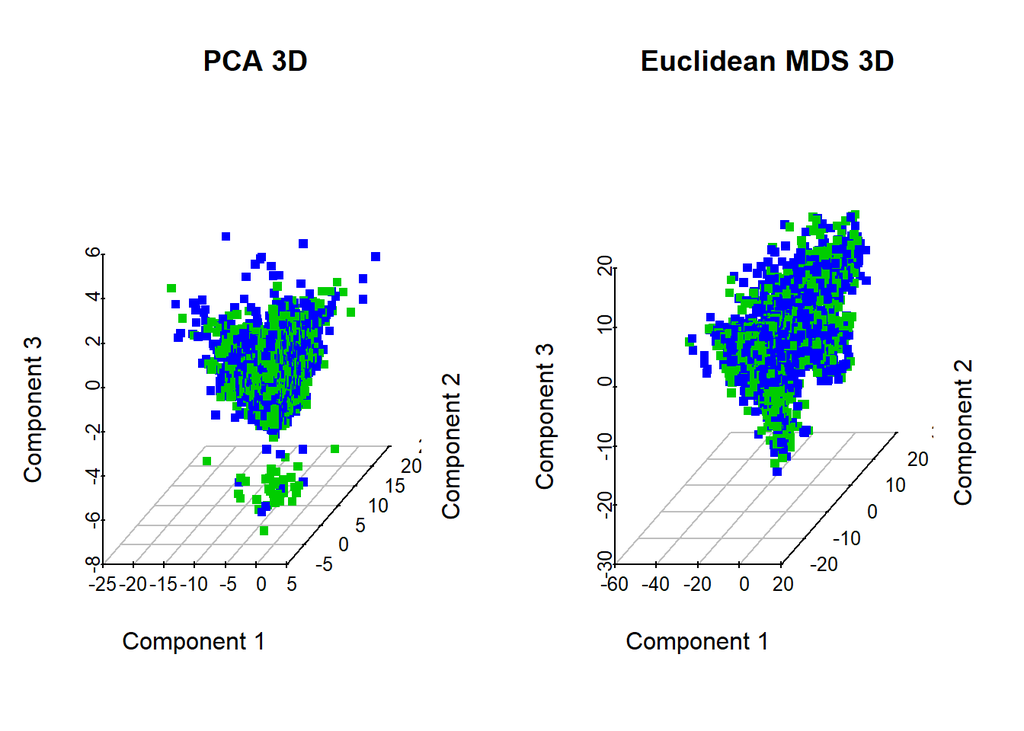

The results seem to follow a similar pattern.

# Task 2

PCA is conducted for match outcomes.

```r
pca_2<-princomp(result_wide_fin, cor=T)
summary(pca_2, loadings=F)
```

```
## Importance of components:
##                           Comp.1    Comp.2     Comp.3     Comp.4
## Standard deviation     3.1907964 2.1785139 1.30780861 1.19534248
## Proportion of Variance 0.4072473 0.1898369 0.06841453 0.05715375
## Cumulative Proportion  0.4072473 0.5970842 0.66549871 0.72265246
##                            Comp.5     Comp.6     Comp.7    Comp.8
## Standard deviation     1.11230847 1.05576735 1.00761009 0.9666334
## Proportion of Variance 0.04948921 0.04458579 0.04061112 0.0373752
## Cumulative Proportion  0.77214166 0.81672745 0.85733857 0.8947138
##                            Comp.9   Comp.10    Comp.11   Comp.12
## Standard deviation     0.88405146 0.8123577 0.75714986 0.6222458
## Proportion of Variance 0.03126188 0.0263970 0.02293104 0.0154876
## Cumulative Proportion  0.92597565 0.9523727 0.97530370 0.9907913
##                            Comp.13     Comp.14     Comp.15      Comp.16
## Standard deviation     0.300067317 0.174525931 0.136373937 0.1230594770
## Proportion of Variance 0.003601616 0.001218372 0.000743914 0.0006057454
## Cumulative Proportion  0.994392907 0.995611279 0.996355193 0.9969609382
##                             Comp.17      Comp.18      Comp.19      Comp.20
## Standard deviation     0.1170496951 0.1116131537 0.1004739241 0.0962349599
## Proportion of Variance 0.0005480252 0.0004982998 0.0004038004 0.0003704467
## Cumulative Proportion  0.9975089635 0.9980072633 0.9984110637 0.9987815104
##                             Comp.21      Comp.22      Comp.23      Comp.24
## Standard deviation     0.0934258576 0.0838514205 0.0791187228 0.0658666516
## Proportion of Variance 0.0003491356 0.0002812424 0.0002503909 0.0001735366
## Cumulative Proportion  0.9991306460 0.9994118884 0.9996622793 0.9998358160
##                            Comp.25
## Standard deviation     0.064067160
## Proportion of Variance 0.000164184
## Cumulative Proportion  1.000000000
```

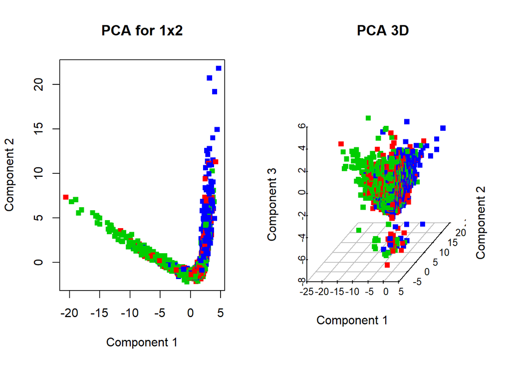

# Task 3

An image of mine with size 200x200 pixel (due to performance restriction) is selected to perform this task.

### Part 1

```r
library(EBImage)
image <- readImage("photo_200.jpg")
```

### Part 2

```r
dim(image)
```

```
## [1] 200 200   3
```

```r
str(image)
```

```
## Formal class 'Image' [package "EBImage"] with 2 slots
##   ..@ .Data    : num [1:200, 1:200, 1:3] 1 1 1 1 1 1 1 1 1 1 ...
##   ..@ colormode: int 2
```

#### a

Here is the image that going to be used in the following steps.

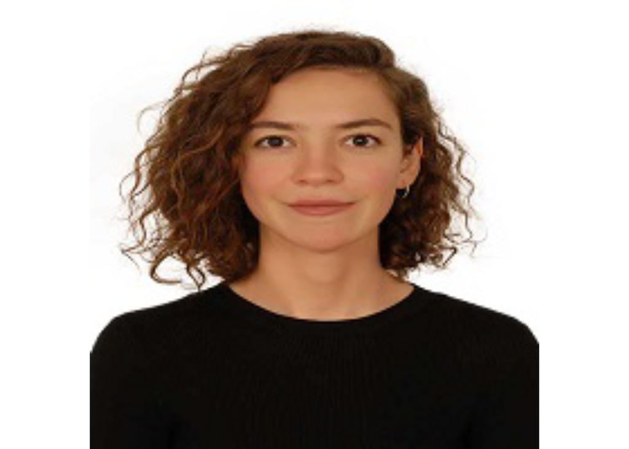

```r
display(image, method = 'raster')
```

Since the image is in RGB format, it has 3 color channels:

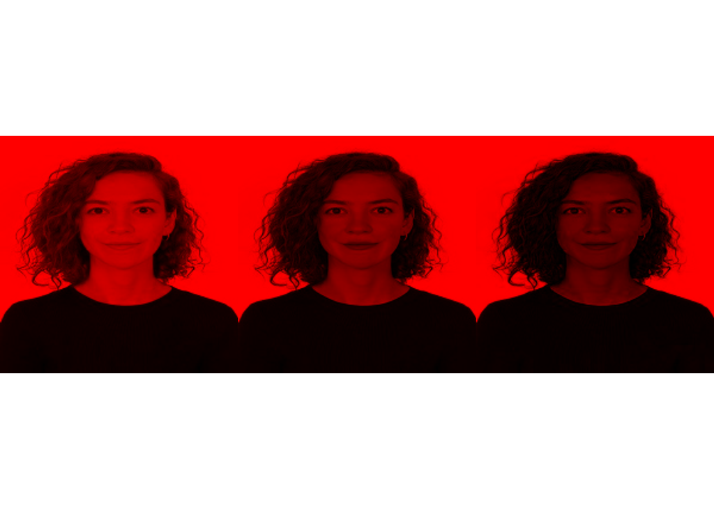

### Part 3

In order to have a noisy image, a random noise has been added to the each pixel of the image.

```r
l = length(image)
image_noisy = image + runif(l, min=0, max=0.1)
```

Here is the noisy image:

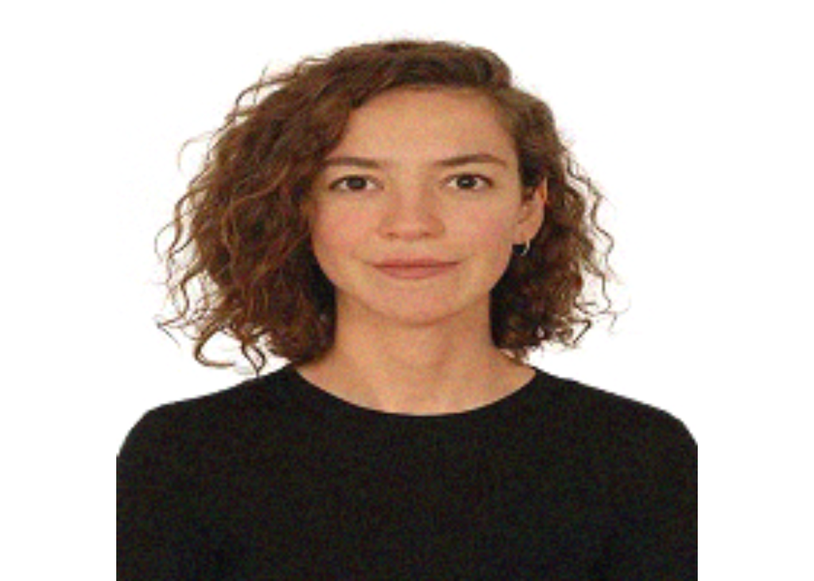

All there channels of the noisy image can be seen below.

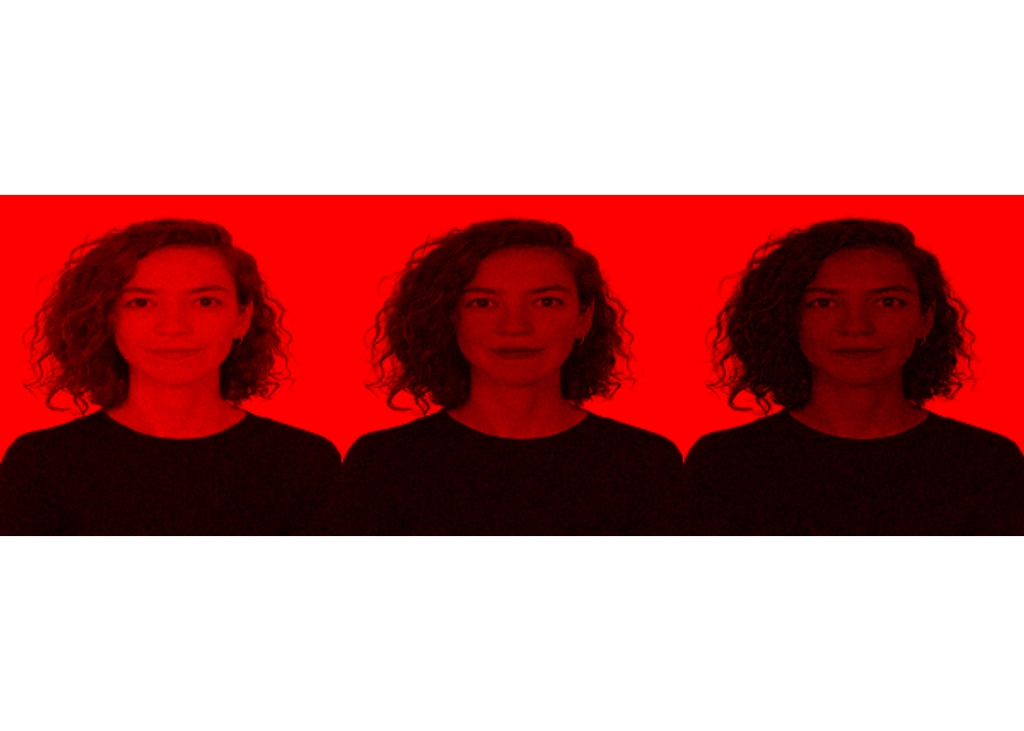

### Part 4

The noisy image has been turned into a single channel grayscale image.

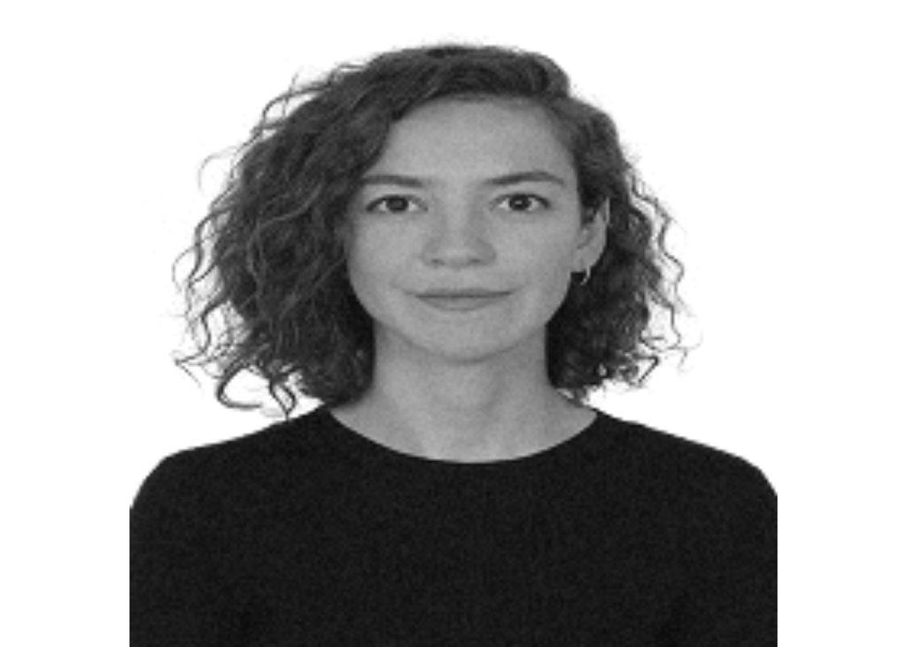

```r
grayimage<-channel(image_noisy,"gray")
```

In order to apply PCA, patches extracted from the image by sliding a 3x3 window and they all stored as a vector length of 9.

```r
y <- 200-2
x <- 1:y
n <- y*y

A <- as.data.frame(matrix(nrow=n,ncol=9))

count= 1
  for (i in x){
    for(j in x){
      A[count,] <- (grayimage[i:(i+2),j:(j+2)])
      count=count+1
    }
  }

head(A)
```

```
##         V1       V2       V3       V4       V5       V6       V7       V8
## 1 1.047096 1.037758 1.028602 1.034758 1.074673 1.036959 1.056174 1.067806
## 2 1.034758 1.074673 1.036959 1.056174 1.067806 1.041230 1.038279 1.082604
## 3 1.056174 1.067806 1.041230 1.038279 1.082604 1.040336 1.048494 1.051206
## 4 1.038279 1.082604 1.040336 1.048494 1.051206 1.067879 1.058628 1.027955
## 5 1.048494 1.051206 1.067879 1.058628 1.027955 1.056253 1.029426 1.049294
## 6 1.058628 1.027955 1.056253 1.029426 1.049294 1.081034 1.074355 1.064616
##         V9
## 1 1.041230
## 2 1.040336
## 3 1.067879
## 4 1.056253
## 5 1.081034
## 6 1.021515
```

#### a

```r
pca<-princomp(A,cor=T)
summary(pca, loadings=T)
```

```
## Importance of components:
##                          Comp.1     Comp.2      Comp.3      Comp.4
## Standard deviation     2.956480 0.30439484 0.252698565 0.163942989
## Proportion of Variance 0.971197 0.01029514 0.007095174 0.002986367
## Cumulative Proportion  0.971197 0.98149212 0.988587298 0.991573665
##                            Comp.5      Comp.6      Comp.7      Comp.8
## Standard deviation     0.14343233 0.125253246 0.124256015 0.114269183
## Proportion of Variance 0.00228587 0.001743153 0.001715506 0.001450827
## Cumulative Proportion  0.99385954 0.995602689 0.997318195 0.998769022
##                             Comp.9
## Standard deviation     0.105255879
## Proportion of Variance 0.001230978
## Cumulative Proportion  1.000000000
##
## Loadings:
##    Comp.1 Comp.2 Comp.3 Comp.4 Comp.5 Comp.6 Comp.7 Comp.8 Comp.9
## V1  0.332  0.418  0.343  0.540  0.153  0.105  0.427  0.163  0.251
## V2  0.334  0.438                0.178 -0.471 -0.224 -0.511 -0.362
## V3  0.332  0.361 -0.419 -0.437  0.345  0.198 -0.170  0.405  0.204
## V4  0.334         0.451        -0.354  0.374 -0.484  0.231 -0.359
## V5  0.336               -0.185 -0.635 -0.404                0.535
## V6  0.334        -0.451        -0.351  0.358  0.506 -0.213 -0.360
## V7  0.332 -0.360  0.423 -0.437  0.345  0.201  0.172 -0.404  0.196
## V8  0.333 -0.442                0.179 -0.490  0.204  0.508 -0.348
## V9  0.332 -0.418 -0.346  0.540  0.150  0.132 -0.420 -0.168  0.244
```

[figure not shown]

```
## integer(0)
```

It can be easily observed that %99 of the variance is covered by the first three component of PCA.

#### b

Image can be reconstructed using components of PCA (See Appendix A).

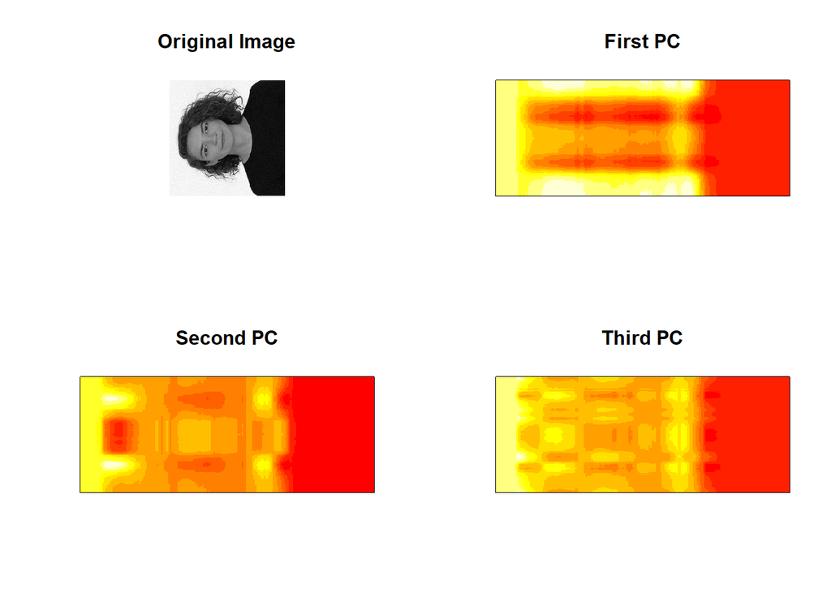

Here is the image obtained by combining all three components:

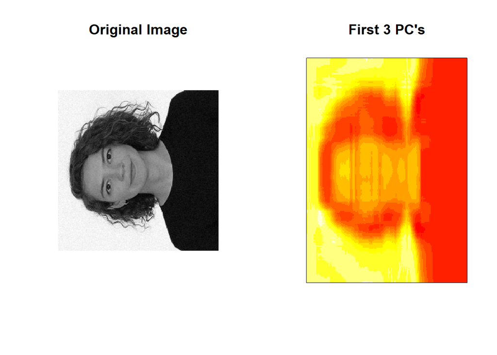

# APPENDIX A

```r
afterPCA <- function(
  matAdjust = 'Centered matrix',
  meanList = 'List of column means of original (unadjusted) matrix',
  eigenList = 'List of eigenvalues and eigenvectors of adjust matrix covariance matrix',
  n = 'selected PC\'s',
  specific_select = 'If False: n == 1:n, if True: just n\'th columns') {

  if (!specific_select) n <- 1:n

  t(eigenList$vectors[,n] %*% (t(eigenList$vectors[,n]) %*% t(matAdjust))) + t(matrix(meanList, nrow = nrow(matAdjust), ncol = ncol(matAdjust)))
}


showMatrix <- function(x, ...) image(t(x[nrow(x):1,]), xaxt = 'none', yaxt = 'none',...)

reconstMatrix <- afterPCA(
  matAdjust = apply(grayimage, 2, function(i) i - mean(i)),
  meanList = apply(grayimage, 2, mean),
  eigenList = pca,
  n = 3,
  specific_select = FALSE
)

par(mfrow = c(1,2))
showMatrix(grayimage, main = 'Original Image')
showMatrix(reconstMatrix, main = 'First 3 PC\'s')
```